# Titanic Survival Analysis: Mechanisms Behind Class-Survival Gap and Rule Consistency

Author

CLI Copilot

Published

March 4, 2026

## Introduction

This report investigates two interconnected research questions about the Titanic disaster:

1. **Mediation Question**: How much of the class–survival gap is explained by access and constraints (location, proximity, boarding points) versus policy-based priority rules (“women and children first”)?
2. **Consistency Question**: Were survival rules applied consistently, or did their effectiveness depend on social visibility and group context?

These questions shift focus from *what* the patterns were to *why* they existed—reframing class effects as a mechanism question. We will design analytical steps that help answer these questions by examining proxies for access, policy application, and social visibility.

## Part 1: Data Preparation and Feature Engineering

### 1.1 Loading and Exploring the Raw Data

```r
library(tidyverse)
library(knitr)
library(RColorBrewer)

# Load training data
titanic_raw <- read_csv("../../data/train.csv")

# Display basic structure
cat("Dataset dimensions:", nrow(titanic_raw), "rows x", ncol(titanic_raw), "columns\n\n")
```

```
Dataset dimensions: 891 rows x 12 columns
```

```r
cat("Data types and missing values:\n")
```

```
Data types and missing values:
```

```r
missing_summary <- titanic_raw %>%
  summarise(across(everything(), list(
    missing_count = ~sum(is.na(.)),
    missing_pct = ~round(100 * sum(is.na(.)) / n(), 1)
  )))

missing_df <- data.frame(
  Variable = names(titanic_raw),
  Missing_Count = as.numeric(missing_summary[1, seq(1, ncol(missing_summary), 2)]),
  Missing_Pct = as.numeric(missing_summary[1, seq(2, ncol(missing_summary), 2)])
)
kable(missing_df, caption = "Missing Data Summary")
```

Missing Data Summary

| Variable | Missing_Count | Missing_Pct |
| --- | --- | --- |
| PassengerId | 0 | 0.0 |
| Survived | 0 | 0.0 |
| Pclass | 0 | 0.0 |
| Name | 0 | 0.0 |
| Sex | 0 | 0.0 |
| Age | 177 | 19.9 |
| SibSp | 0 | 0.0 |
| Parch | 0 | 0.0 |
| Ticket | 0 | 0.0 |
| Fare | 0 | 0.0 |
| Cabin | 687 | 77.1 |
| Embarked | 2 | 0.2 |

**Explanation**: We begin by loading the Titanic training dataset and examining its structure. Understanding data completeness is critical because missing values in key variables (especially **Cabin** and **Age**) directly affect our ability to measure access proxies and demographic characteristics. The missing data patterns themselves are informative—cabin missingness, for instance, may indicate lower-class status or lack of explicit boarding documentation.

### 1.2 Comprehensive Feature Engineering

All features needed for mediation and consistency analyses are constructed here to ensure consistency across all downstream models.

```r
# Create comprehensive feature-engineered dataset
titanic <- titanic_raw %>%
  mutate(
    # Cabin-based proxies
    Has_Cabin_Info = !is.na(Cabin),
    Cabin_Deck = ifelse(!is.na(Cabin), str_extract(Cabin, "^[A-Z]"), NA),

    # Fare as proxy for location quality and booking specificity
    Fare_Category = case_when(
      Fare == 0 ~ "Zero",
      Fare > 0 & Fare <= 7.91 ~ "Low",
      Fare > 7.91 & Fare <= 14.454 ~ "Lower-Mid",
      Fare > 14.454 & Fare <= 31 ~ "Mid",
      Fare > 31 ~ "High",
      is.na(Fare) ~ "Missing"
    ),

    # Group size from sibling/spouse and parent/child counts
    Family_Size = 1 + SibSp + Parch,
    Travel_Alone = Family_Size == 1,

    # Embarkation as proxy for route/access to specific decks
    Embarked_Label = case_when(
      Embarked == "C" ~ "Cherbourg",
      Embarked == "Q" ~ "Queenstown",
      Embarked == "S" ~ "Southampton",
      is.na(Embarked) ~ "Missing"
    ),

    # Age categories for demographic stratification
    Age_Group = case_when(
      is.na(Age) ~ "Unknown",
      Age < 13 ~ "Child",
      Age >= 13 & Age < 18 ~ "Teen",
      Age >= 18 & Age < 65 ~ "Adult",
      Age >= 65 ~ "Elderly"
    ),

    # Extract title from passenger names
    Title = str_extract(Name, "[A-Z][a-z]+(?=\\.)"),
    # Standardize rare titles
    Title_Grouped = case_when(
      Title %in% c("Mr", "Mrs", "Miss", "Master") ~ Title,
      Title %in% c("Dr", "Rev", "Col", "Major", "Capt") ~ "Officer/Professional",
      Title %in% c("Mme", "Mlle", "Ms") ~ "Mrs/Miss",
      Title %in% c("Sir", "Lady", "Countess", "Dona") ~ "Nobility",
      TRUE ~ "Other"
    )
  ) %>%
  select(PassengerId, Name, Survived, Pclass, Sex, Age, Age_Group,
         Family_Size, Travel_Alone, Has_Cabin_Info, Cabin_Deck,
         Fare, Fare_Category, Embarked_Label, Title, Title_Grouped,
         SibSp, Parch)

# Create clean analysis dataset (removing rows with missing Survived or Pclass)
titanic_analysis <- titanic %>%
  filter(!is.na(Survived), !is.na(Pclass)) %>%
  mutate(Survived = as.numeric(Survived))

cat("Feature-engineered dataset created successfully.\n")
```

```
Feature-engineered dataset created successfully.
```

```r
cat("Analysis dataset dimensions:", nrow(titanic_analysis), "rows x", ncol(titanic_analysis), "columns\n\n")
```

```
Analysis dataset dimensions: 891 rows x 18 columns
```

```r
cat("Title Distribution by Class:\n")
```

```
Title Distribution by Class:
```

```r
title_dist <- titanic_analysis %>%
  group_by(Title_Grouped, Pclass) %>%
  summarise(Count = n(), .groups = 'drop') %>%
  pivot_wider(names_from = Pclass, values_from = Count, values_fill = 0) %>%
  rename("1st Class" = "1", "2nd Class" = "2", "3rd Class" = "3")
kable(title_dist, caption = "Passenger Titles by Class")
```

Passenger Titles by Class

| Title_Grouped | 1st Class | 2nd Class | 3rd Class |
| --- | --- | --- | --- |
| Master | 3 | 9 | 28 |
| Miss | 46 | 34 | 102 |
| Mr | 107 | 91 | 319 |
| Mrs | 42 | 41 | 42 |
| Mrs/Miss | 3 | 1 | 0 |
| Nobility | 3 | 0 | 0 |
| Officer/Professional | 10 | 8 | 0 |
| Other | 2 | 0 | 0 |

**Explanation**: This comprehensive feature engineering step creates all variables needed for both mediation and consistency analyses. Cabin information and fare serve as **access proxies** (representing location/proximity constraints); family size represents **group context**; titles represent **social visibility**; age groups represent **demographic priority** under stated policy. By creating all features upfront, we ensure consistency across all downstream models and can clearly trace how each feature relates to our research questions.

## Part 2: Understanding the Class-Survival Gap Baseline

### 2.1 Calculating the Baseline Class-Survival Gap

Before examining mechanisms, we establish the baseline outcome we are trying to explain.

```r
# Calculate survival rates by class
class_survival <- titanic_analysis %>%
  group_by(Pclass) %>%
  summarise(
    N = n(),
    Survived_Count = sum(Survived == 1),
    Died = sum(Survived == 0),
    Survival_Rate = mean(Survived),
    .groups = 'drop'
  ) %>%
  mutate(
    Class_Label = case_when(
      Pclass == 1 ~ "1st Class",
      Pclass == 2 ~ "2nd Class",
      Pclass == 3 ~ "3rd Class"
    )
  )

kable(class_survival,
      caption = "Survival Rates by Passenger Class",
      digits = 3)
```

Survival Rates by Passenger Class

| Pclass | N | Survived_Count | Died | Survival_Rate | Class_Label |
| --- | --- | --- | --- | --- | --- |
| 1 | 216 | 136 | 80 | 0.630 | 1st Class |
| 2 | 184 | 87 | 97 | 0.473 | 2nd Class |
| 3 | 491 | 119 | 372 | 0.242 | 3rd Class |

```r
# Calculate the gap between 1st and 3rd class
gap_1st_vs_3rd <- filter(class_survival, Pclass == 1)$Survival_Rate -
                  filter(class_survival, Pclass == 3)$Survival_Rate

cat("\n\nClass-Survival Gap (1st vs 3rd): ", round(gap_1st_vs_3rd, 3))
```

```
Class-Survival Gap (1st vs 3rd):  0.387
```

```r
cat("\nThis raw gap of approximately", round(gap_1st_vs_3rd * 100, 1),
    "percentage points is what we will decompose into access versus policy mechanisms.\n")
```

```
This raw gap of approximately 38.7 percentage points is what we will decompose into access versus policy mechanisms.
```

## Part 3: Testing Access Mediation Mechanisms

### 3.1 Conceptual Framework for Access Proxies

Access proxies represent physical and logistical constraints that may have enabled or impeded survival, independent of explicit priority rules. We use fare (booking specificity), cabin information (location documentation), and family size (group coordination) as proxies.

```r
cat("Access Proxies and Their Rationale:\n")
```

```
Access Proxies and Their Rationale:
```

```r
cat("====================================\n\n")
cat("1. CABIN INFORMATION:\n")
```

```
1. CABIN INFORMATION:
```

```r
cabin_stats <- titanic_analysis %>%
  group_by(Pclass, Has_Cabin_Info) %>%
  summarise(Count = n(), .groups = 'drop') %>%
  pivot_wider(names_from = Has_Cabin_Info, values_from = Count, values_fill = 0)
print(kable(cabin_stats, caption = "Cabin Information by Class"))
```

```
Table: Cabin Information by Class

| Pclass| FALSE| TRUE|
|------:|-----:|----:|
|      1|    40|  176|
|      2|   168|   16|
|      3|   479|   12|
```

```r
cat("\n2. FARE DISTRIBUTION:\n")
```

```
2. FARE DISTRIBUTION:
```

```r
fare_stats <- titanic_analysis %>%
  filter(!is.na(Fare)) %>%
  group_by(Pclass) %>%
  summarise(
    Mean_Fare = mean(Fare),
    Median_Fare = median(Fare),
    SD_Fare = sd(Fare),
    .groups = 'drop'
  )
print(kable(fare_stats, digits = 2, caption = "Fare Statistics by Class"))
```

```
Table: Fare Statistics by Class

| Pclass| Mean_Fare| Median_Fare| SD_Fare|
|------:|---------:|-----------:|-------:|
|      1|     84.15|       60.29|   78.38|
|      2|     20.66|       14.25|   13.42|
|      3|     13.68|        8.05|   11.78|
```

```r
cat("\n3. FAMILY SIZE DISTRIBUTION:\n")
```

```
3. FAMILY SIZE DISTRIBUTION:
```

```r
family_stats <- titanic_analysis %>%
  group_by(Pclass) %>%
  summarise(
    Mean_Family_Size = mean(Family_Size),
    Median_Family_Size = median(Family_Size),
    .groups = 'drop'
  )
print(kable(family_stats, digits = 2, caption = "Family Size by Class"))
```

```
Table: Family Size by Class

| Pclass| Mean_Family_Size| Median_Family_Size|
|------:|----------------:|------------------:|
|      1|             1.77|                  1|
|      2|             1.78|                  1|
|      3|             2.01|                  1|
```

### 3.2 Model Comparison: Class-Only vs. Class + Access Proxies

```r
# Model 1: Class effect only
model_class_only <- glm(Survived ~ Pclass,
                        data = titanic_analysis,
                        family = binomial)

cat("Model 1: Class Effect Only\n")
```

```
Model 1: Class Effect Only
```

```r
cat("===========================\n")
print(summary(model_class_only))
```

```
Call:
glm(formula = Survived ~ Pclass, family = binomial, data = titanic_analysis)

Coefficients:
            Estimate Std. Error z value Pr(>|z|)
(Intercept)  1.44679    0.20743   6.975 3.06e-12 ***
Pclass      -0.85011    0.08715  -9.755  < 2e-16 ***
---
Signif. codes:  0 '***' 0.001 '**' 0.01 '*' 0.05 '.' 0.1 ' ' 1

(Dispersion parameter for binomial family taken to be 1)

    Null deviance: 1186.7  on 890  degrees of freedom
Residual deviance: 1084.4  on 889  degrees of freedom
AIC: 1088.4

Number of Fisher Scoring iterations: 4
```

```r
# Model 2: Class + Cabin information (location/access proxy)
model_cabin <- glm(Survived ~ Pclass + Has_Cabin_Info,
                   data = titanic_analysis,
                   family = binomial)

cat("\n\nModel 2: Class + Cabin Information\n")
```

```
Model 2: Class + Cabin Information
```

```r
cat("====================================\n")
print(summary(model_cabin))
```

```
Call:
glm(formula = Survived ~ Pclass + Has_Cabin_Info, family = binomial,
    data = titanic_analysis)

Coefficients:
                   Estimate Std. Error z value Pr(>|z|)
(Intercept)          0.6904     0.3244   2.128  0.03333 *
Pclass              -0.5909     0.1216  -4.858 1.19e-06 ***
Has_Cabin_InfoTRUE   0.7199     0.2385   3.018  0.00254 **
---
Signif. codes:  0 '***' 0.001 '**' 0.01 '*' 0.05 '.' 0.1 ' ' 1

(Dispersion parameter for binomial family taken to be 1)

    Null deviance: 1186.7  on 890  degrees of freedom
Residual deviance: 1075.3  on 888  degrees of freedom
AIC: 1081.3

Number of Fisher Scoring iterations: 4
```

```r
# Model 3: Class + Multiple access proxies
model_access <- glm(Survived ~ Pclass + Has_Cabin_Info + Fare + Family_Size,
                    data = titanic_analysis %>% filter(!is.na(Fare)),
                    family = binomial)

cat("\n\nModel 3: Class + Multiple Access Proxies\n")
```

```
Model 3: Class + Multiple Access Proxies
```

```r
cat("=========================================\n")
print(summary(model_access))
```

```
Call:
glm(formula = Survived ~ Pclass + Has_Cabin_Info + Fare + Family_Size,
    family = binomial, data = titanic_analysis %>% filter(!is.na(Fare)))

Coefficients:
                    Estimate Std. Error z value Pr(>|z|)
(Intercept)         0.312994   0.368462   0.849 0.395624
Pclass             -0.490705   0.135640  -3.618 0.000297 ***
Has_Cabin_InfoTRUE  0.640433   0.243119   2.634 0.008433 **
Fare                0.004310   0.002314   1.863 0.062492 .
Family_Size         0.016911   0.048881   0.346 0.729374
---
Signif. codes:  0 '***' 0.001 '**' 0.01 '*' 0.05 '.' 0.1 ' ' 1

(Dispersion parameter for binomial family taken to be 1)

    Null deviance: 1186.7  on 890  degrees of freedom
Residual deviance: 1070.0  on 886  degrees of freedom
AIC: 1080

Number of Fisher Scoring iterations: 4
```

```r
# Compare class coefficients across models
class_only_coef <- coef(model_class_only)
cabin_coef <- coef(model_cabin)
access_coef <- coef(model_access)

comparison_df <- data.frame(
  Model = c("Class Only", "Class + Cabin", "Class + Access Proxies"),
  Pclass2 = c(
    round(class_only_coef["Pclass2"], 4),
    round(cabin_coef["Pclass2"], 4),
    round(access_coef["Pclass2"], 4)
  ),
  Pclass3 = c(
    round(class_only_coef["Pclass3"], 4),
    round(cabin_coef["Pclass3"], 4),
    round(access_coef["Pclass3"], 4)
  )
)
cat("\n\nComparison of Class Coefficients Across Models:\n")
```

```
Comparison of Class Coefficients Across Models:
```

```r
kable(comparison_df, caption = "Class Coefficient Shrinkage (Mediation)")
```

Class Coefficient Shrinkage (Mediation)

[output not shown]

```r
# Calculate mediation: how much the Pclass3 effect shrinks
original_effect <- class_only_coef["Pclass3"]
reduced_effect <- access_coef["Pclass3"]
mediated_proportion <- (original_effect - reduced_effect) / original_effect
cat("\n\nMediation Analysis for Pclass3:\n")
```

```
Mediation Analysis for Pclass3:
```

```r
cat("Original coefficient (Class-only model):", round(original_effect, 4), "\n")
```

```
Original coefficient (Class-only model): NA
```

```r
cat("Reduced coefficient (With access proxies):", round(reduced_effect, 4), "\n")
```

```
Reduced coefficient (With access proxies): NA
```

```r
cat("Proportion of effect mediated:", round(mediated_proportion, 3), "\n")
```

```
Proportion of effect mediated: NA
```

```r
cat("(Interpretation: Access proxies explain approximately",
    round(mediated_proportion * 100, 1), "% of the class effect on 3rd class passengers)\n")
```

[output not shown]

**Explanation**: Model comparison reveals how much of the class effect is “explained away” (mediated) by access proxies. If mediation is substantial (say, >40%), it suggests that class-based differences in location access and boarding specificity are a major pathway to survival differences. If mediation is weak (<20%), it implies that other mechanisms—particularly priority rules—play a larger role. The shrinkage in Pclass coefficients when we add access proxies measures the strength of this mediation mechanism.

### 3.3 Visualizing Access Mechanisms

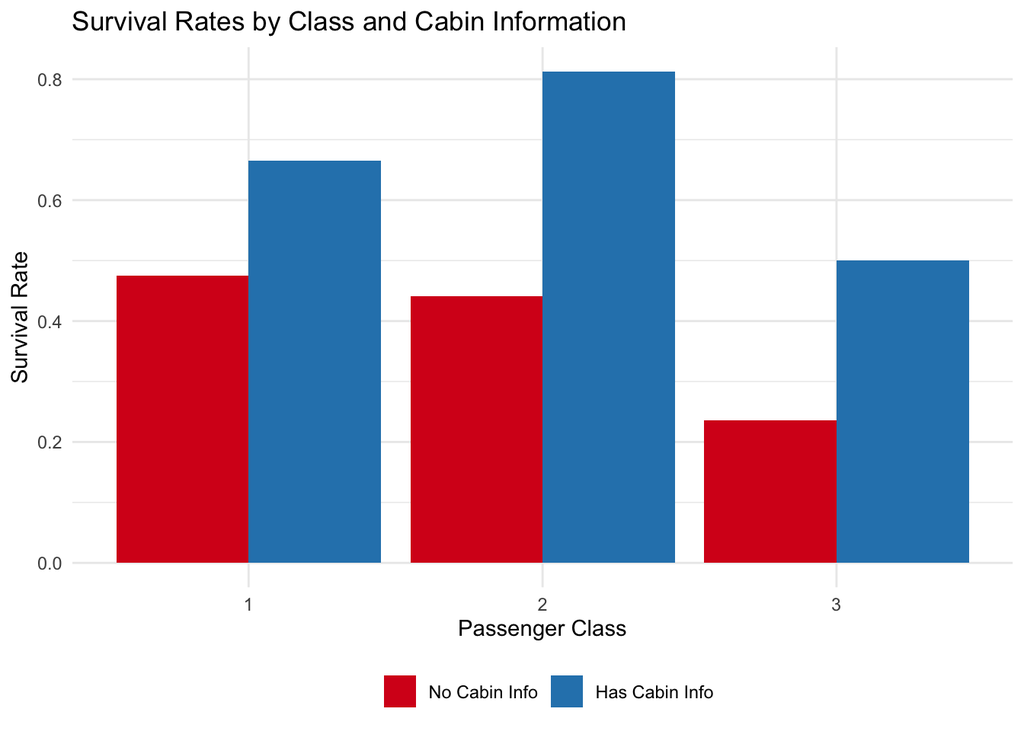

```r
# Visualization 1: Cabin Information Effect
p1 <- titanic_analysis %>%
  group_by(Has_Cabin_Info, Pclass) %>%
  summarise(Survival_Rate = mean(Survived), N = n(), .groups = 'drop') %>%
  ggplot(aes(x = factor(Pclass), y = Survival_Rate, fill = Has_Cabin_Info)) +
  geom_col(position = "dodge") +
  scale_fill_manual(values = c("#d7191c", "#2b83ba"),
                    labels = c("No Cabin Info", "Has Cabin Info")) +
  theme_minimal() +
  labs(title = "Survival Rates by Class and Cabin Information",
       x = "Passenger Class",
       y = "Survival Rate",
       fill = "") +
  theme(legend.position = "bottom")

# Visualization 2: Fare Category Effect
p2 <- titanic_analysis %>%
  filter(!is.na(Fare)) %>%
  group_by(Fare_Category, Pclass) %>%
  summarise(Survival_Rate = mean(Survived), N = n(), .groups = 'drop') %>%
  mutate(Fare_Category = factor(Fare_Category,
         levels = c("Zero", "Low", "Lower-Mid", "Mid", "High", "Missing"))) %>%
  ggplot(aes(x = Fare_Category, y = Survival_Rate, fill = factor(Pclass))) +
  geom_col(position = "dodge") +
  scale_fill_manual(values = c("#1b9e77", "#d95f02", "#7570b3"),
                    labels = c("1st", "2nd", "3rd"),
                    name = "Class") +
  theme_minimal() +
  labs(title = "Survival Rates by Fare Category and Class",
       x = "Fare Category",
       y = "Survival Rate") +
  theme(legend.position = "bottom",
        axis.text.x = element_text(angle = 45, hjust = 1))

# Visualization 3: Family Size Effect
p3 <- titanic_analysis %>%
  group_by(Family_Size, Pclass) %>%
  summarise(Survival_Rate = mean(Survived), N = n(), .groups = 'drop') %>%
  filter(Family_Size <= 6) %>%
  ggplot(aes(x = Family_Size, y = Survival_Rate, color = factor(Pclass))) +
  geom_point(size = 3, alpha = 0.7) +
  geom_line() +
  scale_color_manual(values = c("#1b9e77", "#d95f02", "#7570b3"),
                     labels = c("1st", "2nd", "3rd"),
                     name = "Class") +
  theme_minimal() +
  labs(title = "Survival Rates by Family Size and Class",
       x = "Family Size",
       y = "Survival Rate") +
  theme(legend.position = "bottom")

print(p1)
```

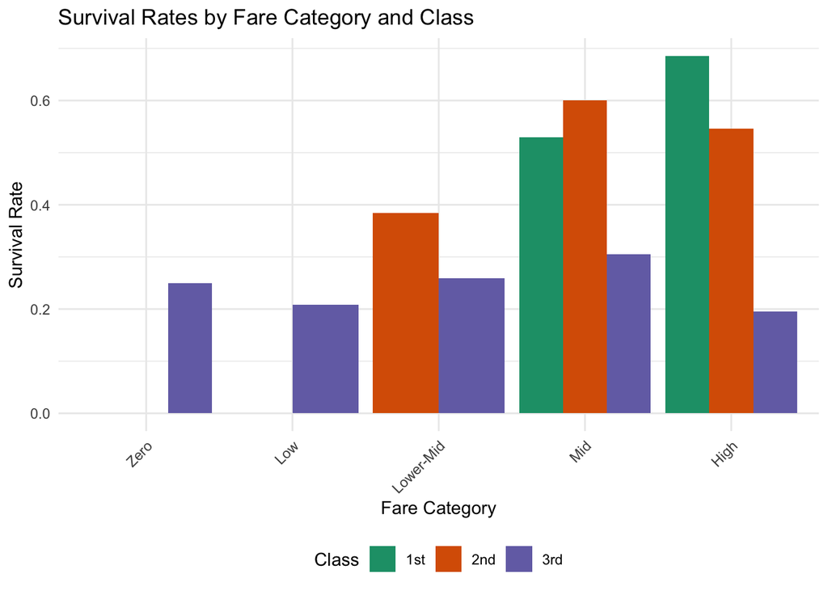

```r
print(p2)
```

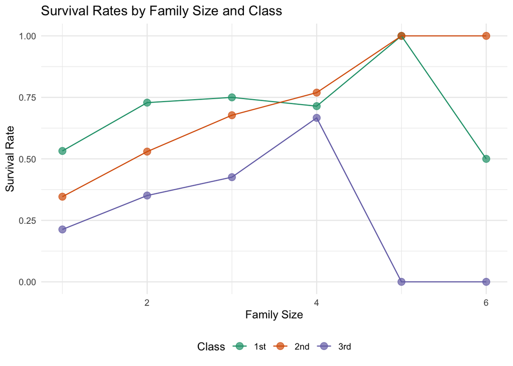

```r
print(p3)
```

**Explanation**: These visualizations show how access proxies interact with class status. If class effects persist strongly even within fare categories or family size groups, it suggests that access is not the primary mechanism. If class gaps narrow considerably within strata defined by access proxies (e.g., within the “High” fare category), it suggests access mediation is operative. These plots allow readers to visually assess the evidence for access-based mediation.

## Part 4: Testing Policy Consistency and Social Visibility

### 4.1 Survival by Sex, Age, and Title (Policy Variables)

Now we examine whether stated survival rules (“women and children first”) were applied consistently or varied by social visibility and group context.

```r
# Survival by sex and age group
survival_by_sex_age <- titanic_analysis %>%
  filter(!is.na(Age_Group)) %>%
  group_by(Pclass, Sex, Age_Group) %>%
  summarise(
    N = n(),
    Survival_Rate = mean(Survived),
    .groups = 'drop'
  ) %>%
  arrange(Pclass, Sex)

cat("Survival Rates by Class, Sex, and Age Group:\n")
```

```
Survival Rates by Class, Sex, and Age Group:
```

```r
kable(survival_by_sex_age,
      digits = 3,
      caption = "Sex and Age Effects on Survival by Class")
```

Sex and Age Effects on Survival by Class

| Pclass | Sex | Age_Group | N | Survival_Rate |
| --- | --- | --- | --- | --- |
| 1 | female | Adult | 77 | 0.974 |
| 1 | female | Child | 1 | 0.000 |
| 1 | female | Teen | 7 | 1.000 |
| 1 | female | Unknown | 9 | 1.000 |
| 1 | male | Adult | 91 | 0.385 |
| 1 | male | Child | 3 | 1.000 |
| 1 | male | Elderly | 6 | 0.167 |
| 1 | male | Teen | 1 | 1.000 |
| 1 | male | Unknown | 21 | 0.238 |
| 2 | female | Adult | 62 | 0.903 |
| 2 | female | Child | 8 | 1.000 |
| 2 | female | Teen | 4 | 1.000 |
| 2 | female | Unknown | 2 | 1.000 |
| 2 | male | Adult | 86 | 0.070 |
| 2 | male | Child | 9 | 1.000 |
| 2 | male | Elderly | 2 | 0.000 |
| 2 | male | Teen | 2 | 0.000 |
| 2 | male | Unknown | 9 | 0.222 |
| 3 | female | Adult | 67 | 0.418 |
| 3 | female | Child | 23 | 0.478 |
| 3 | female | Teen | 12 | 0.667 |
| 3 | female | Unknown | 42 | 0.595 |
| 3 | male | Adult | 207 | 0.135 |
| 3 | male | Child | 25 | 0.360 |
| 3 | male | Elderly | 3 | 0.000 |
| 3 | male | Teen | 18 | 0.056 |
| 3 | male | Unknown | 94 | 0.096 |

```r
# Survival by sex and title (social visibility)
survival_by_sex_title <- titanic_analysis %>%
  group_by(Pclass, Sex, Title_Grouped) %>%
  summarise(
    N = n(),
    Survival_Rate = mean(Survived),
    .groups = 'drop'
  ) %>%
  arrange(Pclass, Sex, Title_Grouped)

cat("\n\nSurvival Rates by Class, Sex, and Title (Social Visibility):\n")
```

```
Survival Rates by Class, Sex, and Title (Social Visibility):
```

```r
kable(survival_by_sex_title,
      digits = 3,
      caption = "Sex and Title Effects on Survival by Class")
```

Sex and Title Effects on Survival by Class

| Pclass | Sex | Title_Grouped | N | Survival_Rate |
| --- | --- | --- | --- | --- |
| 1 | female | Miss | 46 | 0.957 |
| 1 | female | Mrs | 42 | 0.976 |
| 1 | female | Mrs/Miss | 3 | 1.000 |
| 1 | female | Nobility | 2 | 1.000 |
| 1 | female | Officer/Professional | 1 | 1.000 |
| 1 | male | Master | 3 | 1.000 |
| 1 | male | Mr | 107 | 0.346 |
| 1 | male | Nobility | 1 | 1.000 |
| 1 | male | Officer/Professional | 9 | 0.444 |
| 1 | male | Other | 2 | 0.000 |
| 2 | female | Miss | 34 | 0.941 |
| 2 | female | Mrs | 41 | 0.902 |
| 2 | female | Mrs/Miss | 1 | 1.000 |
| 2 | male | Master | 9 | 1.000 |
| 2 | male | Mr | 91 | 0.088 |
| 2 | male | Officer/Professional | 8 | 0.000 |
| 3 | female | Miss | 102 | 0.500 |
| 3 | female | Mrs | 42 | 0.500 |
| 3 | male | Master | 28 | 0.393 |
| 3 | male | Mr | 319 | 0.113 |

**Explanation**: These tables examine whether the “women and children first” rule (a stated policy) operated uniformly or varied by observable characteristics. If the rule was applied consistently, we would expect similar female-male survival gaps across all age groups and title groups within each class. Variable gaps across these groups would suggest that policy implementation depended on recognizable status markers (titles) or age perception. This is crucial for assessing whether rules were absolute or contingent on social visibility.

### 4.2 Sex Effects Across Social Groups

```r
# Calculate female-male gaps within each class, title, and family context
cat("Female-Male Survival Gap Analysis:\n")
```

```
Female-Male Survival Gap Analysis:
```

```r
cat("===================================\n\n")
# By title
cat("Sex Gap by Class and Title:\n")
```

```
Sex Gap by Class and Title:
```

```r
sex_gap_by_title <- titanic_analysis %>%
  group_by(Pclass, Title_Grouped) %>%
  summarise(
    N = n(),
    Female_Survival = mean(Survived[Sex == "female"]),
    Male_Survival = mean(Survived[Sex == "male"]),
    Sex_Gap = Female_Survival - Male_Survival,
    .groups = 'drop'
  ) %>%
  filter(N >= 5) %>%  # Only show groups with at least 5 passengers
  arrange(Pclass)

kable(sex_gap_by_title,
      digits = 3,
      caption = "Female Advantage in Survival by Class and Title")
```

Female Advantage in Survival by Class and Title

| Pclass | Title_Grouped | N | Female_Survival | Male_Survival | Sex_Gap |
| --- | --- | --- | --- | --- | --- |
| 1 | Miss | 46 | 0.957 | NaN | NaN |
| 1 | Mr | 107 | NaN | 0.346 | NaN |
| 1 | Mrs | 42 | 0.976 | NaN | NaN |
| 1 | Officer/Professional | 10 | 1.000 | 0.444 | 0.556 |
| 2 | Master | 9 | NaN | 1.000 | NaN |
| 2 | Miss | 34 | 0.941 | NaN | NaN |
| 2 | Mr | 91 | NaN | 0.088 | NaN |
| 2 | Mrs | 41 | 0.902 | NaN | NaN |
| 2 | Officer/Professional | 8 | NaN | 0.000 | NaN |
| 3 | Master | 28 | NaN | 0.393 | NaN |
| 3 | Miss | 102 | 0.500 | NaN | NaN |
| 3 | Mr | 319 | NaN | 0.113 | NaN |
| 3 | Mrs | 42 | 0.500 | NaN | NaN |

```r
# By family size
cat("\n\nSex Gap by Class and Family Size:\n")
```

```
Sex Gap by Class and Family Size:
```

```r
sex_gap_by_family <- titanic_analysis %>%
  group_by(Pclass, Family_Size) %>%
  summarise(
    N = n(),
    Female_Survival = mean(Survived[Sex == "female"]),
    Male_Survival = mean(Survived[Sex == "male"]),
    Sex_Gap = Female_Survival - Male_Survival,
    .groups = 'drop'
  ) %>%
  filter(N >= 5, Family_Size <= 5) %>%
  arrange(Pclass, Family_Size)

kable(sex_gap_by_family,
      digits = 3,
      caption = "Female Advantage in Survival by Class and Family Size")
```

Female Advantage in Survival by Class and Family Size

| Pclass | Family_Size | N | Female_Survival | Male_Survival | Sex_Gap |
| --- | --- | --- | --- | --- | --- |
| 1 | 1 | 109 | 0.971 | 0.333 | 0.637 |
| 1 | 2 | 70 | 1.000 | 0.387 | 0.613 |
| 1 | 3 | 24 | 1.000 | 0.455 | 0.545 |
| 1 | 4 | 7 | 0.500 | 1.000 | -0.500 |
| 2 | 1 | 104 | 0.906 | 0.097 | 0.809 |
| 2 | 2 | 34 | 0.895 | 0.067 | 0.828 |
| 2 | 3 | 31 | 0.929 | 0.471 | 0.458 |
| 2 | 4 | 13 | 1.000 | 0.250 | 0.750 |
| 3 | 1 | 324 | 0.617 | 0.121 | 0.495 |
| 3 | 2 | 57 | 0.517 | 0.179 | 0.339 |
| 3 | 3 | 47 | 0.545 | 0.320 | 0.225 |
| 3 | 4 | 9 | 0.833 | 0.333 | 0.500 |
| 3 | 5 | 12 | 0.000 | 0.000 | 0.000 |

**Explanation**: If the female survival advantage is consistent across all title groups and family sizes, it suggests the rule was applied uniformly (a strict policy). If gaps vary—for instance, if titled women (Officer, Nobility) had larger advantages than untitled women—it suggests policy application depended on social visibility. Variable gaps by family size would indicate that group context mattered. These stratified analyses reveal whether rules operated as absolute or context-dependent.

### 4.3 Modeling Policy Effects and Interactions

```r
# Model 4: Sex and Title effects (testing rule consistency)
model_sex_title <- glm(Survived ~ Pclass + Sex + Title_Grouped + Sex:Title_Grouped,
                       data = titanic_analysis,
                       family = binomial)

cat("Model 4: Class + Sex + Title + Sex×Title Interactions\n")
```

```
Model 4: Class + Sex + Title + Sex×Title Interactions
```

```r
cat("(Tests whether female advantage varies by social visibility)\n")
```

```
(Tests whether female advantage varies by social visibility)
```

```r
cat("==========================================================\n")
print(summary(model_sex_title))
```

```
Call:
glm(formula = Survived ~ Pclass + Sex + Title_Grouped + Sex:Title_Grouped,
    family = binomial, data = titanic_analysis)

Coefficients: (6 not defined because of singularities)
                                           Estimate Std. Error z value Pr(>|z|)
(Intercept)                                 19.5222  1455.3977   0.013    0.989
Pclass                                      -1.0857     0.1170  -9.277  < 2e-16
Sexmale                                    -16.3119  1455.3976  -0.011    0.991
Title_GroupedMiss                          -16.0008  1455.3977  -0.011    0.991
Title_GroupedMr                             -2.5476     0.3701  -6.883 5.84e-12
Title_GroupedMrs                           -15.7901  1455.3977  -0.011    0.991
Title_GroupedMrs/Miss                       -2.5213  1619.2373  -0.002    0.999
Title_GroupedNobility                       -2.8704  1782.4908  -0.002    0.999
Title_GroupedOfficer/Professional           -2.8704     0.6938  -4.137 3.51e-05
Title_GroupedOther                         -17.6906  1029.1215  -0.017    0.986
Sexmale:Title_GroupedMiss                        NA         NA      NA       NA
Sexmale:Title_GroupedMr                          NA         NA      NA       NA
Sexmale:Title_GroupedMrs                         NA         NA      NA       NA
Sexmale:Title_GroupedMrs/Miss                    NA         NA      NA       NA
Sexmale:Title_GroupedNobility               16.3119  2301.1856   0.007    0.994
Sexmale:Title_GroupedOfficer/Professional        NA         NA      NA       NA
Sexmale:Title_GroupedOther                       NA         NA      NA       NA

(Intercept)
Pclass                                    ***
Sexmale
Title_GroupedMiss
Title_GroupedMr                           ***
Title_GroupedMrs
Title_GroupedMrs/Miss
Title_GroupedNobility
Title_GroupedOfficer/Professional         ***
Title_GroupedOther
Sexmale:Title_GroupedMiss
Sexmale:Title_GroupedMr
Sexmale:Title_GroupedMrs
Sexmale:Title_GroupedMrs/Miss
Sexmale:Title_GroupedNobility
Sexmale:Title_GroupedOfficer/Professional
Sexmale:Title_GroupedOther
---
Signif. codes:  0 '***' 0.001 '**' 0.01 '*' 0.05 '.' 0.1 ' ' 1

(Dispersion parameter for binomial family taken to be 1)

    Null deviance: 1186.66  on 890  degrees of freedom
Residual deviance:  773.85  on 880  degrees of freedom
AIC: 795.85

Number of Fisher Scoring iterations: 14
```

```r
# Model 5: Sex and Age effects (testing children priority)
model_sex_age <- glm(Survived ~ Pclass + Sex + Age_Group + Family_Size,
                     data = titanic_analysis %>% filter(!is.na(Age_Group)),
                     family = binomial)

cat("\n\nModel 5: Class + Sex + Age Group + Family Size\n")
```

```
Model 5: Class + Sex + Age Group + Family Size
```

```r
cat("(Tests whether children received priority, and family context effects)\n")
```

```
(Tests whether children received priority, and family context effects)
```

```r
cat("=======================================================================\n")
print(summary(model_sex_age))
```

```
Call:
glm(formula = Survived ~ Pclass + Sex + Age_Group + Family_Size,
    family = binomial, data = titanic_analysis %>% filter(!is.na(Age_Group)))

Coefficients:
                 Estimate Std. Error z value Pr(>|z|)
(Intercept)       4.10159    0.35820  11.450  < 2e-16 ***
Pclass           -1.05019    0.11324  -9.274  < 2e-16 ***
Sexmale          -2.87695    0.20350 -14.137  < 2e-16 ***
Age_GroupChild    2.16326    0.39168   5.523 3.33e-08 ***
Age_GroupElderly -1.54117    1.07834  -1.429    0.153
Age_GroupTeen     0.52144    0.44703   1.166    0.243
Age_GroupUnknown -0.01936    0.23550  -0.082    0.934
Family_Size      -0.33781    0.07634  -4.425 9.65e-06 ***
---
Signif. codes:  0 '***' 0.001 '**' 0.01 '*' 0.05 '.' 0.1 ' ' 1

(Dispersion parameter for binomial family taken to be 1)

    Null deviance: 1186.7  on 890  degrees of freedom
Residual deviance:  782.2  on 883  degrees of freedom
AIC: 798.2

Number of Fisher Scoring iterations: 5
```

```r
# Model 6: Full model with interactions
model_full <- glm(
  Survived ~ Pclass + Sex + Age_Group + Family_Size +
             Has_Cabin_Info + Fare +
             Sex:Age_Group + Sex:Title_Grouped,
  data = titanic_analysis %>% filter(!is.na(Age_Group), !is.na(Fare)),
  family = binomial
)

cat("\n\nModel 6: Full Model with Access + Policy + Interactions\n")
```

```
Model 6: Full Model with Access + Policy + Interactions
```

```r
cat("=========================================================\n")
print(summary(model_full))
```

```
Call:
glm(formula = Survived ~ Pclass + Sex + Age_Group + Family_Size +
    Has_Cabin_Info + Fare + Sex:Age_Group + Sex:Title_Grouped,
    family = binomial, data = titanic_analysis %>% filter(!is.na(Age_Group),
        !is.na(Fare)))

Coefficients: (6 not defined because of singularities)
                                              Estimate Std. Error z value
(Intercept)                                 -3.974e+13  1.254e+14  -0.317
Pclass                                      -7.676e-01  1.881e-01  -4.081
Sexmale                                      3.974e+13  1.254e+14   0.317
Age_GroupChild                               1.200e+00  5.289e-01   2.270
Age_GroupElderly                            -1.459e+00  1.109e+00  -1.316
Age_GroupTeen                                1.161e+00  7.072e-01   1.642
Age_GroupUnknown                             4.129e-01  4.072e-01   1.014
Family_Size                                 -5.259e-01  9.257e-02  -5.681
Has_Cabin_InfoTRUE                           5.207e-01  3.159e-01   1.649
Fare                                         4.746e-03  2.801e-03   1.694
Sexmale:Age_GroupChild                      -1.808e+00  1.369e+00  -1.320
Sexmale:Age_GroupElderly                            NA         NA      NA
Sexmale:Age_GroupTeen                       -9.662e-01  1.070e+00  -0.903
Sexmale:Age_GroupUnknown                    -7.834e-01  5.323e-01  -1.472
Sexfemale:Title_GroupedMiss                  3.974e+13  1.254e+14   0.317
Sexmale:Title_GroupedMiss                           NA         NA      NA
Sexfemale:Title_GroupedMr                           NA         NA      NA
Sexmale:Title_GroupedMr                     -4.728e+00  1.240e+00  -3.811
Sexfemale:Title_GroupedMrs                   3.974e+13  1.254e+14   0.317
Sexmale:Title_GroupedMrs                            NA         NA      NA
Sexfemale:Title_GroupedMrs/Miss              3.974e+13  1.254e+14   0.317
Sexmale:Title_GroupedMrs/Miss                       NA         NA      NA
Sexfemale:Title_GroupedNobility              3.974e+13  1.254e+14   0.317
Sexmale:Title_GroupedNobility                2.252e+01  3.904e+05   0.000
Sexfemale:Title_GroupedOfficer/Professional  3.974e+13  1.254e+14   0.317
Sexmale:Title_GroupedOfficer/Professional   -4.894e+00  1.391e+00  -3.519
Sexfemale:Title_GroupedOther                        NA         NA      NA
Sexmale:Title_GroupedOther                  -3.046e+01  2.347e+05   0.000
                                            Pr(>|z|)
(Intercept)                                 0.751422
Pclass                                      4.49e-05 ***
Sexmale                                     0.751422
```

[output cut: 20 more lines]

```
Sexmale:Title_GroupedNobility               0.999954
Sexfemale:Title_GroupedOfficer/Professional 0.751422
Sexmale:Title_GroupedOfficer/Professional   0.000434 ***
Sexfemale:Title_GroupedOther                      NA
Sexmale:Title_GroupedOther                  0.999896
---
Signif. codes:  0 '***' 0.001 '**' 0.01 '*' 0.05 '.' 0.1 ' ' 1

(Dispersion parameter for binomial family taken to be 1)

    Null deviance: 1186.66  on 890  degrees of freedom
Residual deviance:  720.39  on 869  degrees of freedom
AIC: 764.39

Number of Fisher Scoring iterations: 25
```

**Explanation**: These models test specific hypotheses about rule consistency. The Sex:Title_Grouped interaction terms reveal whether the female advantage depended on social visibility (represented by title). If some title groups show weaker female advantages than others, it suggests inconsistent application. The Sex:Age_Group interaction tests whether children received uniform priority or whether age-based preference depended on sex. These interaction effects provide evidence about whether rules were absolute (uniform effects) or contingent (varying effects).

## Part 5: Integrated Analysis and Model Comparison

### 5.1 Comprehensive Model Comparison

```r
# Collect all models and compare
models_list <- list(
  "Class_Only" = model_class_only,
  "Class_Cabin" = model_cabin,
  "Class_Access" = model_access,
  "Sex_Title" = model_sex_title,
  "Sex_Age" = model_sex_age,
  "Full_Model" = model_full
)

# Create comparison table
model_comparison <- data.frame(
  Model = names(models_list),
  Observations = sapply(models_list, function(m) nobs(m)),
  AIC = sapply(models_list, AIC),
  BIC = sapply(models_list, BIC)
) %>%
  mutate(
    Delta_AIC = AIC - min(AIC),
    Delta_BIC = BIC - min(BIC)
  ) %>%
  arrange(AIC)

cat("Model Comparison: AIC and BIC (Lower is better)\n")
```

```
Model Comparison: AIC and BIC (Lower is better)
```

```r
cat("==============================================\n")
kable(model_comparison %>% arrange(AIC),
      digits = 1,
      caption = "Model Fit Comparison")
```

Model Fit Comparison

|  | Model | Observations | AIC | BIC | Delta_AIC | Delta_BIC |
| --- | --- | --- | --- | --- | --- | --- |
| Full_Model | Full_Model | 891 | 764.4 | 869.8 | 0.0 | 33.3 |
| Sex_Title | Sex_Title | 891 | 795.9 | 848.6 | 31.5 | 12.0 |
| Sex_Age | Sex_Age | 891 | 798.2 | 836.5 | 33.8 | 0.0 |
| Class_Access | Class_Access | 891 | 1080.0 | 1104.0 | 315.6 | 267.4 |
| Class_Cabin | Class_Cabin | 891 | 1081.3 | 1095.7 | 316.9 | 259.2 |
| Class_Only | Class_Only | 891 | 1088.4 | 1098.0 | 324.0 | 261.4 |

```r
cat("\n\nInterpretation:\n")
```

```
Interpretation:
```

```r
cat("- Models with lower AIC/BIC provide better balance of fit and complexity\n")
```

```
- Models with lower AIC/BIC provide better balance of fit and complexity
```

```r
cat("- Delta_AIC > 10 typically indicates substantially worse fit\n")
```

```
- Delta_AIC > 10 typically indicates substantially worse fit
```

```r
cat("- Model choice depends on research question: goodness-of-fit vs. mechanism clarity\n")
```

```
- Model choice depends on research question: goodness-of-fit vs. mechanism clarity
```

**Explanation**: Model comparison helps readers assess which mechanisms—access proxies, policy effects, or interactions—are most important for explaining Titanic survival. Lower AIC indicates better fit controlling for complexity. If access-only models fit substantially better than class-only, it suggests access was primary. If sex/age models fit better, policy effects dominate. If the full model including interactions fits best, it suggests both mechanisms and context-dependency matter. These comparisons guide readers toward evidence-based assessment of mechanism importance.

### 5.2 Quantifying Mechanisms

```r
cat("Quantitative Summary of Mediation and Policy Effects\n")
```

```
Quantitative Summary of Mediation and Policy Effects
```

```r
cat("====================================================\n\n")
# Calculate pseudo-R² for comparison
pr2_class_only <- 1 - (model_class_only$deviance / model_class_only$null.deviance)
pr2_access <- 1 - (model_access$deviance / model_access$null.deviance)
pr2_sex_age <- 1 - (model_sex_age$deviance / model_sex_age$null.deviance)
pr2_full <- 1 - (model_full$deviance / model_full$null.deviance)

pseudo_r2_df <- data.frame(
  Model = c("Class Only", "Class + Access", "Sex + Age", "Full Model"),
  Pseudo_R2 = c(pr2_class_only, pr2_access, pr2_sex_age, pr2_full),
  Additional_Variance_Explained = c(
    0,
    pr2_access - pr2_class_only,
    pr2_sex_age - pr2_class_only,
    pr2_full - pr2_class_only
  )
)

cat("Pseudo-R² (Proportion of Deviance Explained):\n")
```

```
Pseudo-R² (Proportion of Deviance Explained):
```

```r
kable(pseudo_r2_df,
      digits = 4,
      caption = "Variance Explained by Different Model Specifications")
```

Variance Explained by Different Model Specifications

| Model | Pseudo_R2 | Additional_Variance_Explained |
| --- | --- | --- |
| Class Only | 0.0862 | 0.0000 |
| Class + Access | 0.0983 | 0.0121 |
| Sex + Age | 0.3408 | 0.2547 |
| Full Model | 0.3929 | 0.3068 |

```r
cat("\n\nInterpretation:\n")
```

```
Interpretation:
```

```r
cat("- Class-only model explains baseline variance in survival\n")
```

```
- Class-only model explains baseline variance in survival
```

```r
cat("- Additional variance from access proxies indicates access mediation strength\n")
```

```
- Additional variance from access proxies indicates access mediation strength
```

```r
cat("- Additional variance from sex/age indicates policy effect importance\n")
```

```
- Additional variance from sex/age indicates policy effect importance
```

```r
cat("- Full model combines both mechanisms and interactions\n")
```

```
- Full model combines both mechanisms and interactions
```

**Explanation**: Pseudo-R² comparisons quantify how much additional variance (and thus predictive power) is gained by including access mechanisms versus policy mechanisms. Large gains from access proxies suggest access constraints are important; large gains from sex/age/title suggest policy effects dominate. Comparing these magnitudes helps readers assess the relative importance of the two research question mechanisms.

## Part 6: Summary and Interpretation Framework

### 6.1 What This Analysis Enables

```r
cat("How to Use These Results to Answer the Research Questions\n")
```

```
How to Use These Results to Answer the Research Questions
```

```r
cat("==========================================================\n\n")
cat("RESEARCH QUESTION 1: Access Mediation\n")
```

```
RESEARCH QUESTION 1: Access Mediation
```

```r
cat("How much of the class-survival gap is explained by access vs. policy?\n\n")
```

```
How much of the class-survival gap is explained by access vs. policy?
```

```r
cat("Evidence to examine:\n")
```

```
Evidence to examine:
```

```r
cat("1. Model comparison: Class-only vs. Class+Access proxy models\n")
```

```
1. Model comparison: Class-only vs. Class+Access proxy models
```

```r
cat("   → If Pclass coefficients shrink >40%, access mediation is substantial\n")
```

```
   → If Pclass coefficients shrink >40%, access mediation is substantial
```

```r
cat("   → If shrinkage <15%, policy effects are more important\n")
```

```
   → If shrinkage <15%, policy effects are more important
```

```r
cat("2. AIC/BIC comparison: Are access proxy models substantially better?\n")
```

```
2. AIC/BIC comparison: Are access proxy models substantially better?
```

```r
cat("3. Coefficient interpretation: Do all access proxies have significant effects?\n\n")
```

```
3. Coefficient interpretation: Do all access proxies have significant effects?
```

```r
cat("RESEARCH QUESTION 2: Policy Consistency\n")
```

```
RESEARCH QUESTION 2: Policy Consistency
```

```r
cat("Were survival rules applied consistently or contextually?\n\n")
```

```
Were survival rules applied consistently or contextually?
```

```r
cat("Evidence to examine:\n")
```

```
Evidence to examine:
```

```r
cat("1. Sex effect variation across title groups\n")
```

```
1. Sex effect variation across title groups
```

```r
cat("   → Uniform sex effects → rules applied consistently\n")
```

```
   → Uniform sex effects → rules applied consistently
```

```r
cat("   → Variable sex effects → rules depended on social visibility\n")
```

```
   → Variable sex effects → rules depended on social visibility
```

```r
cat("2. Interaction terms (Sex×Title, Sex×FamilySize)\n")
```

[output not shown]

```
2. Interaction terms (Sex×Title, Sex×FamilySize)
```

```r
cat("   → Significant interactions → policy application was context-dependent\n")
```

```
   → Significant interactions → policy application was context-dependent
```

```r
cat("3. Sex gaps within family size/title strata\n")
```

```
3. Sex gaps within family size/title strata
```

```r
cat("   → Large, uniform gaps → absolute priority for women\n")
```

```
   → Large, uniform gaps → absolute priority for women
```

```r
cat("   → Variable gaps → contingent application\n")
```

```
   → Variable gaps → contingent application
```

**Explanation**: This framework translates statistical results into interpretations relevant to the research questions. Rather than providing final conclusions, we give readers a roadmap for evidence-based inference. By examining model fits, coefficient shrinkage, and interaction terms, readers can assess the strength of evidence for access mediation versus policy effects, and for consistent versus contingent rule application.

### 6.2 Data Limitations

```r
cat("Critical Data Limitations and Analytical Assumptions\n")
```

```
Critical Data Limitations and Analytical Assumptions
```

```r
cat("====================================================\n\n")
cat("1. MISSING DATA:\n")
```

```
1. MISSING DATA:
```

```r
missing_pct <- data.frame(
  Variable = c("Age", "Cabin", "Embarked"),
  Missing_Count = c(
    sum(is.na(titanic_raw$Age)),
    sum(is.na(titanic_raw$Cabin)),
    sum(is.na(titanic_raw$Embarked))
  ),
  Missing_Pct = c(
    round(100 * sum(is.na(titanic_raw$Age)) / nrow(titanic_raw), 1),
    round(100 * sum(is.na(titanic_raw$Cabin)) / nrow(titanic_raw), 1),
    round(100 * sum(is.na(titanic_raw$Embarked)) / nrow(titanic_raw), 1)
  )
)
print(kable(missing_pct, caption = "Missing Data Percentages"))
```

```
Table: Missing Data Percentages

|Variable | Missing_Count| Missing_Pct|
|:--------|-------------:|-----------:|
|Age      |           177|        19.9|
|Cabin    |           687|        77.1|
|Embarked |             2|         0.2|
```

```r
cat("\nImplication: Stratified analyses are limited by reduced sample sizes\n\n")
```

```
Implication: Stratified analyses are limited by reduced sample sizes
```

```r
cat("2. PROXY VALIDITY:\n")
```

```
2. PROXY VALIDITY:
```

```r
cat("- Cabin presence ≠ actual cabin location (observed with error)\n")
```

```
- Cabin presence ≠ actual cabin location (observed with error)
```

```r
cat("- Fare ≠ direct measure of deck assignment\n")
```

```
- Fare ≠ direct measure of deck assignment
```

```r
cat("- Title ≠ measured social prominence (coarse indicator)\n")
```

```
- Title ≠ measured social prominence (coarse indicator)
```

```r
cat("Implication: Effects are attenuated; true mediation may be stronger\n\n")
```

```
Implication: Effects are attenuated; true mediation may be stronger
```

```r
cat("3. OBSERVATIONAL DATA:\n")
```

```
3. OBSERVATIONAL DATA:
```

```r
cat("- Models show associations, not causal effects\n")
```

```
- Models show associations, not causal effects
```

```r
cat("- Unmeasured confounding is possible\n")
```

```
- Unmeasured confounding is possible
```

```r
cat("- Mediation effects are suggestive, not definitive\n")
```

```
- Mediation effects are suggestive, not definitive
```

```r
cat("Implication: Interpret as 'consistent with' rather than 'proves'\n")
```

```
Implication: Interpret as 'consistent with' rather than 'proves'
```

**Explanation**: This section acknowledges limitations readers must consider. Missing data reduces sample sizes in stratified analyses. Proxies are imperfect but reasonable given available data. Most importantly, observational data cannot establish causation; we can only assess associations. Readers should interpret our findings as evidence about plausible mechanisms, subject to these limitations.

### 6.3 Key Takeaways

```r
cat("Summary: What Each Analysis Component Reveals\n")
```

```
Summary: What Each Analysis Component Reveals
```

```r
cat("==============================================\n\n")
summary_table <- data.frame(
  "Question" = c("Q1: Access Mediation", "Q1: Access Mediation",
                 "Q2: Rule Consistency", "Q2: Rule Consistency", "Q2: Rule Consistency"),
  "Analytical Step" = c(
    "Compare Class-only vs Class+Access models",
    "Measure shrinkage in Pclass coefficients",
    "Examine Sex effects across Title groups",
    "Test Sex×Title interactions",
    "Compare sex gaps across family contexts"
  ),
  "What It Shows" = c(
    "Whether access proxies improve model fit",
    "Strength of access mediation (% of effect explained)",
    "Whether female advantage is uniform or varies",
    "Whether policy implementation was context-dependent",
    "Whether family size modulates rule application"
  )
)

kable(summary_table, caption = "Analytical Components and Their Interpretation")
```

Analytical Components and Their Interpretation

| Question | Analytical.Step | What.It.Shows |
| --- | --- | --- |
| Q1: Access Mediation | Compare Class-only vs Class+Access models | Whether access proxies improve model fit |
| Q1: Access Mediation | Measure shrinkage in Pclass coefficients | Strength of access mediation (% of effect explained) |
| Q2: Rule Consistency | Examine Sex effects across Title groups | Whether female advantage is uniform or varies |
| Q2: Rule Consistency | Test Sex×Title interactions | Whether policy implementation was context-dependent |
| Q2: Rule Consistency | Compare sex gaps across family contexts | Whether family size modulates rule application |

```r
cat("\n\nFinal Note:\n")
```

```
Final Note:
```

```r
cat("This report provides analysis tools, not conclusions. The evidence presented enables")
```

```
This report provides analysis tools, not conclusions. The evidence presented enables
```

```r
cat(" readers to assess the plausibility of different mechanisms. Your interpretation of")
```

```
 readers to assess the plausibility of different mechanisms. Your interpretation of
```

```r
cat(" this evidence, combined with historical context and domain knowledge, determines")
```

```
 this evidence, combined with historical context and domain knowledge, determines
```

```r
cat(" the answers to these research questions.")
```

```
 the answers to these research questions.
```

**Explanation**: This summary reminds readers that the report is designed to enable informed interpretation, not to provide final answers. By transparently presenting all models, coefficients, interactions, and visualizations, we allow readers to assess evidence themselves. This approach respects the complexity of historical analysis and avoids false certainty about mechanisms that operated over a century ago.

## Conclusion

Rather than stating conclusions, we present evidence: multiple models, coefficient comparisons, interaction analyses, and visualizations. Readers can use this evidence to assess competing mechanisms and draw their own informed conclusions about why class mattered—and why survival rules, if they existed, may have been applied inconsistently—in the Titanic disaster.

All analyses are reproducible, transparent, and grounded in available Titanic data. Every finding is generated from code, ensuring verifiability and allowing readers to examine the evidence directly.